# Nepal Population Map Metadata Report

## Prediction Weighting Layer Used in Population Redistribution

The data presented below represent the predicted number of people per ~100 m pixel as estimated using the random forest (RF) model as described in Stevens, et al. ([2015](http://journals.plos.org/plosone/article?id=10.1371/journal.pone.0107042)). The following pages contain a description of the RF model and its covariates, their sources and any metadata collected for each covariate. The prediction weighting layer is used to dasymetrically redistribute the census counts and project counts to match estimated populations based on UN estimates for the final population maps provided by WorldPop.

###### Stevens, F. R., Gaughan, A. E., Linard, C., & Tatem, A. J. (2015). Disaggregating Census Data for Population Mapping Using Random Forests with Remotely-Sensed and Ancillary Data. [PLOS ONE, 10(2), e0107042. doi:10.1371/journal.pone.0107042](http://journals.plos.org/plosone/article?id=10.1371/journal.pone.0107042)

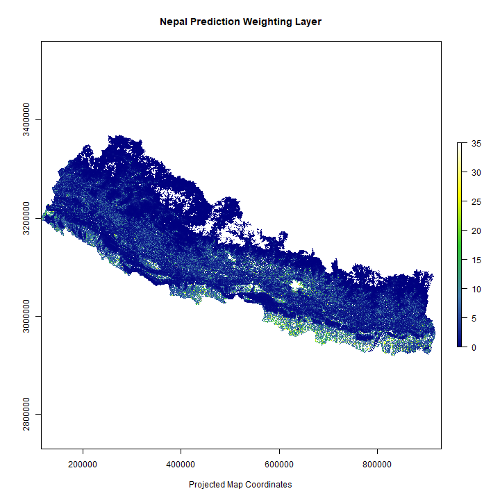

## Nepal Census Data and Observed Population Density

These data are the population density values used to estimate the RF model used to create the prediction weighting layer you see above. Values represent population density as measured by people per hectare and calculated from population counts within each census unit. These values are used as the dependent variable during model estimation.

### Nepal Census Data, 2011, Admin-level 5

**Folder:** Census  
**File Name:** census.shp  
**Source:** Central Bureau of Statistics of Nepal  
**Description:** These census data were acquired in April 2014 for use in WorldPop endeavors. Required fields for map production are ADMINID and ADMINPOP  
**Class:** polygon  
**Derived Covariates:**  
area, buff, zones,

```
class       : SpatialPolygonsDataFrame
features    : 36036
extent      : 115788, 916842, 2918485, 3370757  (xmin, xmax, ymin, ymax)
coord. ref. : NA
variables   : 18
```

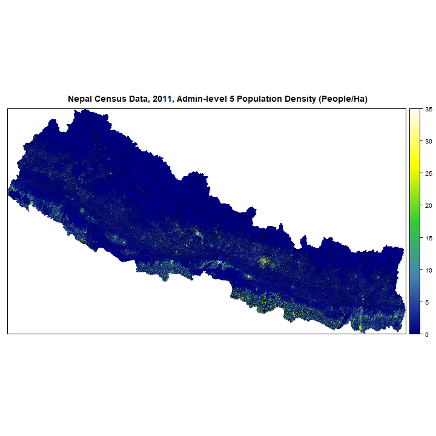

## Random Forest Model and Diagnostics

These output and figures outline the estimated RF model that is used to predict the population density weighting layer. The model is fitted to the population density values for the preceding census data using covariates aggregatedfrom the ancillary data sources summarized following the model diagnostics.

```
Call:
 randomForest(x = x_data, y = y_data, ntree = popfit$ntree, mtry = popfit$mtry,      nodesize = length(y_data)/1000, importance = TRUE, proximity = F)
               Type of random forest: regression
                     Number of trees: 500
No. of variables tried at each split: 22

          Mean of squared residuals: 0.39
                    % Var explained: 80
```

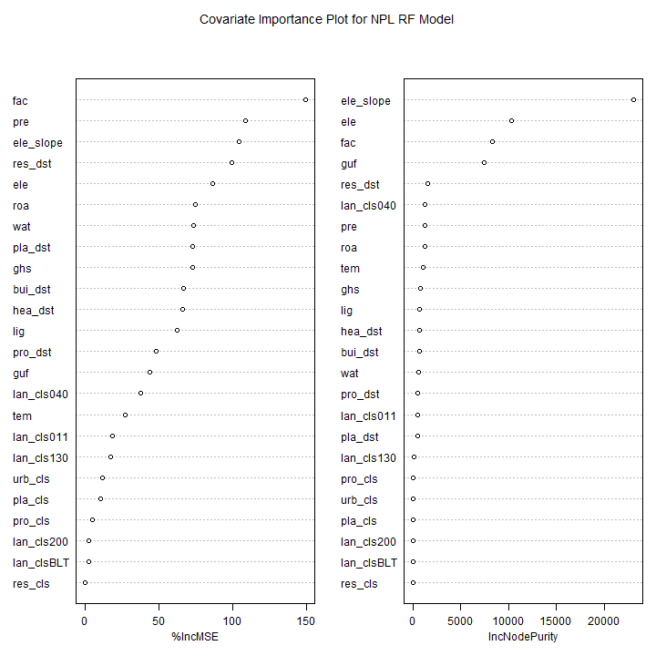

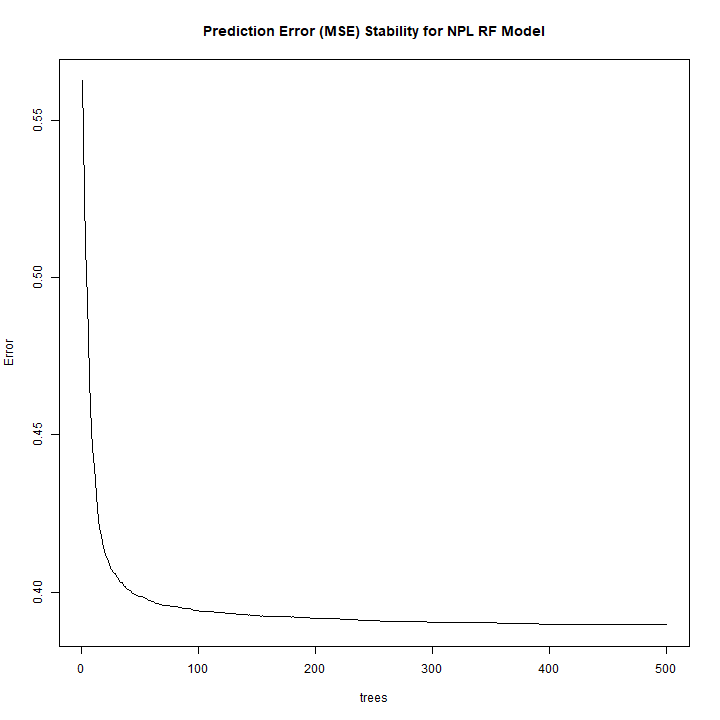

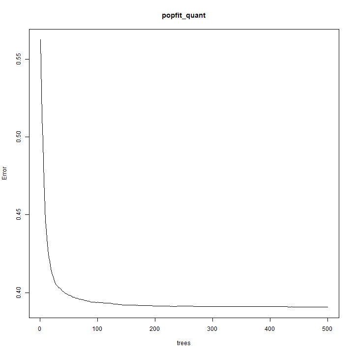

## Covariate Metadata

### Remotely-sensed, ESA Landcover, 300m

**Folder:** Landcover  
**File Name:** npl_lc_rc_nibb_rurb_maj_8bit.tif  
**Source:** http://www.esa-landcover-cci.org/  
**Description:** Land cover information was combined from a GlobCover 2010 coverage and fused with Landsat-derived urban/rural built area classification to construct a single land cover dataset.  
**Class:** raster  
**Derived Covariates:**  
cls011, dte011, cls040, dte040, cls130, dte130, cls140, dte140, cls150, dte150, cls160, dte160, cls190, dte190, cls200, dte200, cls210, dte210, cls230, dte230, cls240, dte240, cls250, dte250, clsBLT, dteBLT,

```
class       : RasterBrick
dimensions  : 5031, 8449, 42506919, 1  (nrow, ncol, ncell, nlayers)
resolution  : 100, 100  (x, y)
extent      : 400103, 1245003, 2901369, 3404469  (xmin, xmax, ymin, ymax)
coord. ref. : +proj=utm +zone=44 +datum=WGS84 +units=m +no_defs +ellps=WGS84 +towgs84=0,0,0
data source : D:\Working_RF\data\NPL\Landcover\Derived\landcover.tif
names       : landcover
min values  :         0
max values  :       240
```

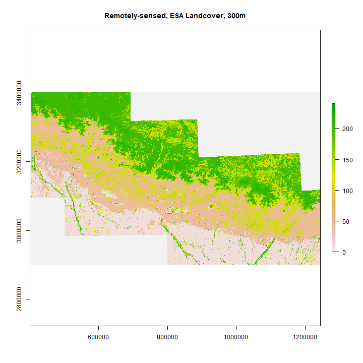

### Suomi NPP VIIRS-Derived 2012 Lights at Night, 15 arc-second

**Folder:** Lights  
**File Name:** DEFAULT: VIIRS 2012  
**Source:** http://ngdc.noaa.gov/eog/viirs/download_viirs_ntl.html  
**Description:** These 'Lights at Night' data were derived from imagery collected by the Defense Meteorological Satellite Program (DMSP) Operational Linescan System (OLS) which has a unique low-light imaging capability, developed for the detection of clouds using moonlight. In addition to moonlit clouds, the OLS also detects lights from human settlements, fires, gas flares, heavily lit fishing boats, lightning and the aurora.  
**Class:** raster  
**Derived Covariates:**  
,

[output not shown]

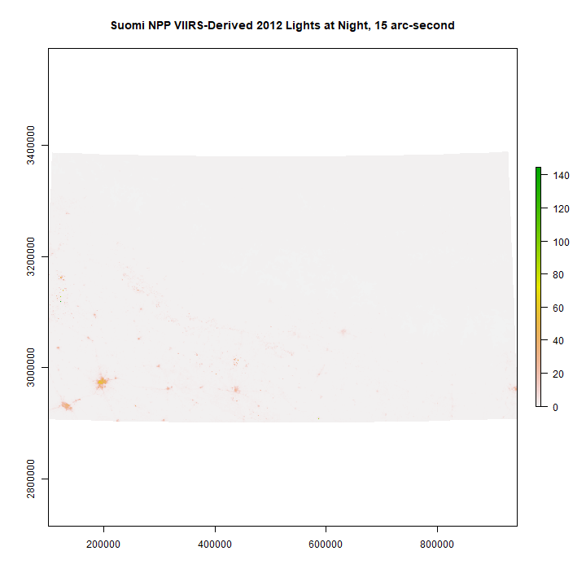

### WorldClim/BioClim Mean Annual Temperature 1950-2000, 30 arc-second

**Folder:** Temp  
**File Name:** DEFAULT: BIO1  
**Source:** http://www.worldclim.org/current  
**Description:** WorldClim/BioClim 1950-2000 mean annual precipitation (BIO12) and mean annual temperature (BIO1) estimates (Hijmans et al., 2005) were downloaded, mosaicked and subset to match the extent of our land cover data for the mapping of this region.  
**Class:** raster  
**Derived Covariates:**  
,

```
class       : RasterBrick
dimensions  : 4896, 8555, 41885280, 1  (nrow, ncol, ncell, nlayers)
resolution  : 100, 100  (x, y)
extent      : 89372, 944872, 2900469, 3390069  (xmin, xmax, ymin, ymax)
coord. ref. : +proj=tmerc +lat_0=0 +lon_0=84 +k=0.9996 +x_0=500000 +y_0=0 +datum=WGS84 +units=m +no_defs +ellps=WGS84 +towgs84=0,0,0
data source : D:\Working_RF\data\NPL\Temp\Derived\temp.tif
names       : temp
min values  : -194
max values  :  259
```

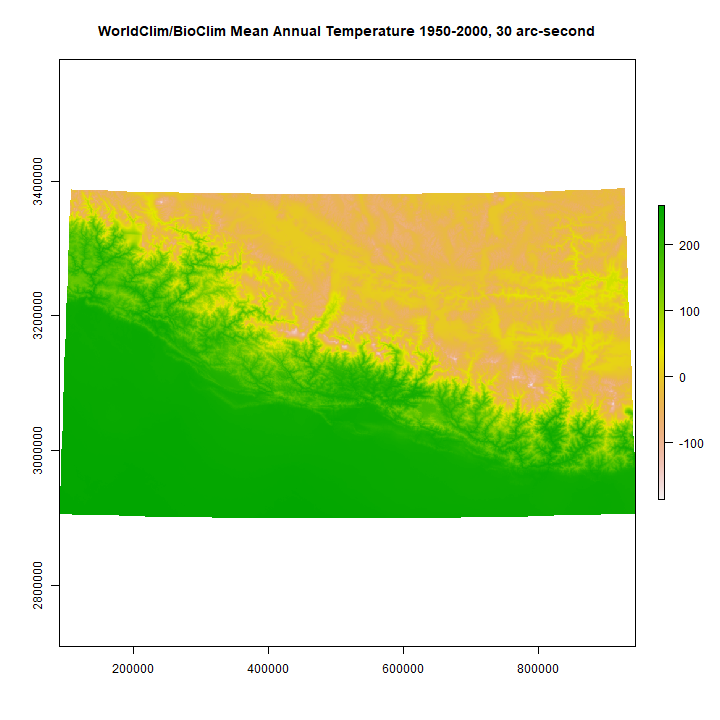

### WorldClim/BioClim Mean Annual Precipitation 1950-2000, 30 arc-second

**Folder:** Precip  
**File Name:** DEFAULT: BIO12  
**Source:** http://www.worldclim.org/current  
**Description:** WorldClim/BioClim 1950-2000 mean annual precipitation (BIO12) and mean annual temperature (BIO1) estimates (Hijmans et al., 2005) were downloaded, mosaicked and subset to match the extent of our land cover data for the mapping of this region.  
**Class:** raster  
**Derived Covariates:**  
,

```
class       : RasterBrick
dimensions  : 4896, 8555, 41885280, 1  (nrow, ncol, ncell, nlayers)
resolution  : 100, 100  (x, y)
extent      : 89372, 944872, 2900469, 3390069  (xmin, xmax, ymin, ymax)
coord. ref. : +proj=tmerc +lat_0=0 +lon_0=84 +k=0.9996 +x_0=500000 +y_0=0 +datum=WGS84 +units=m +no_defs +ellps=WGS84 +towgs84=0,0,0
data source : D:\Working_RF\data\NPL\Precip\Derived\precip.tif
names       : precip
min values  :    186
max values  :   4404
```

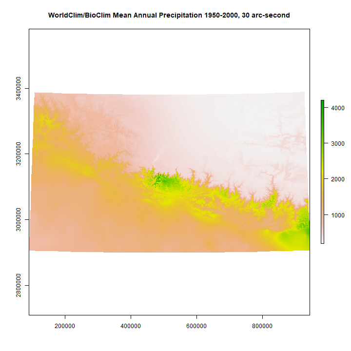

### Waterbodies, Distance-to (OSM) 2017

**Folder:** Waterbodies  
**File Name:** waterbodies_distanceto.tif  
**Source:** Open Street Map, Downloaded 2017-07, http://extract.bbbike.org/  
**Description:** These data were provided at A geometric resolution: original in 0.4 arc seconds (~12 m, near the equator) under a cooperation agreement with the GUF project under the DLR Earth Observation Center.  
**Class:** polygon  
**Derived Covariates:**  
cls, dst,

```
class       : SpatialPolygonsDataFrame
features    : 226
extent      : 111732, 917421, 2915517, 3369520  (xmin, xmax, ymin, ymax)
coord. ref. : +proj=tmerc +lat_0=0 +lon_0=84 +k=0.9996 +x_0=500000 +y_0=0 +datum=WGS84 +units=m +no_defs +ellps=WGS84 +towgs84=0,0,0
variables   : 10
```

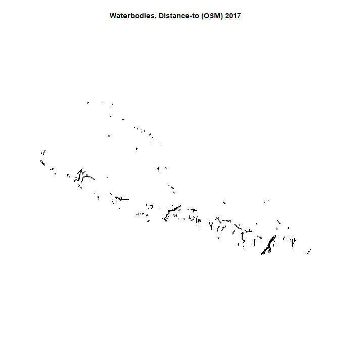

### Protected Areas

**Folder:** Protected  
**File Name:** DEFAULT: WDPAfgdb_Sept2012.gdb  
**Source:** World Database on Protected Areas, Downloaded September, 2012, UNEP, http://www.wdpa.org, http://protectedplanet.net  
**Description:** These data are compiled by UNEP and distributed via the Protected Planet website. All protected areas were downloaded regardless of International Union for Conservation of Nature (IUCN) or any other designation, so they include sanctuaries, national parks, game reserves, World Heritage Sites, etc.  
**Class:** polygon  
**Derived Covariates:**  
cls, dst,

```
class       : SpatialPolygonsDataFrame
features    : 38
extent      : 119036, 924200, 2942830, 3307726  (xmin, xmax, ymin, ymax)
coord. ref. : +proj=tmerc +lat_0=0 +lon_0=84 +k=0.9996 +x_0=500000 +y_0=0 +datum=WGS84 +units=m +no_defs +ellps=WGS84 +towgs84=0,0,0
variables   : 26
```

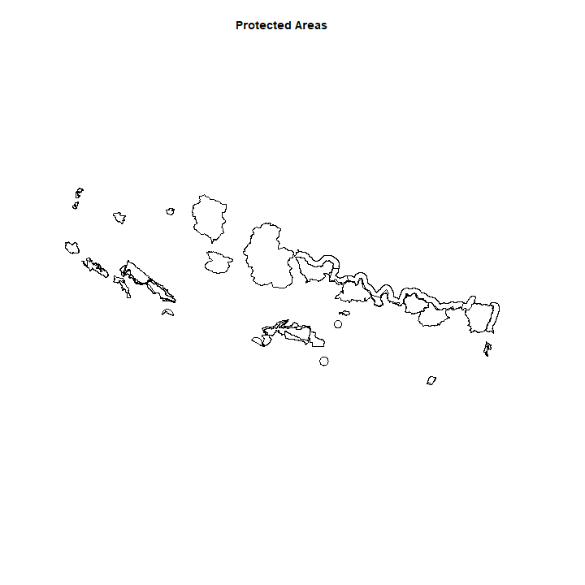

### Urban Extents

**Folder:** Urban  
**File Name:** DEFAULT: schneider-urban.shp  
**Source:** Schneider, et al., United Nations  
**Description:** These data were constructed from MODIS-derived imagery and provided to WorldPop researchers by Schneider, et al. as part of a global urban extents datasets.  
**Class:** polygon  
**Derived Covariates:**  
cls, dte,

```
class       : SpatialPolygonsDataFrame
features    : 240
extent      : 399881, 1209793, 2923379, 3222166  (xmin, xmax, ymin, ymax)
coord. ref. : +proj=utm +zone=44 +datum=WGS84 +units=m +no_defs +ellps=WGS84 +towgs84=0,0,0
variables   : 2
```

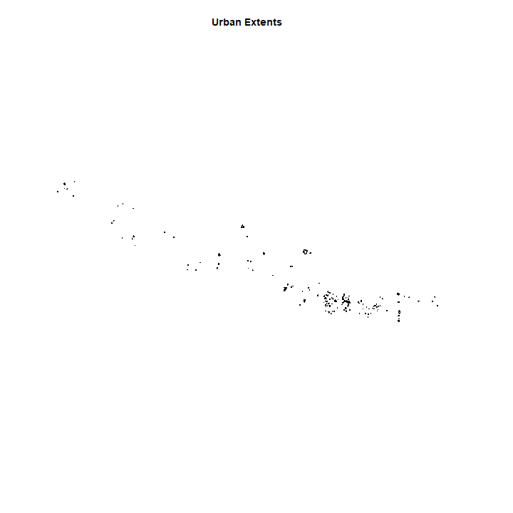

### Elevation and Derived Slope, 3 second

**Folder:** Elevation  
**File Name:** DEFAULT: Void-Filled DEM.gdb  
**Source:** HydroSHEDS Void-Filled DEM (Lehnert, et al., 2006), http://hydrosheds.cr.usgs.gov/dataavail.php  
**Description:** The HydroSHEDS data are the result of an effort to provide a globally consistent dataset consisting of NASA's Shuttle Radar Topography Mission (SRTM) data and have been processed, void-filled and corrected for use at large scales.  
**Class:** raster  
**Derived Covariates:**  
, slope,

```
class       : RasterBrick
dimensions  : 4880, 8549, 41719120, 1  (nrow, ncol, ncell, nlayers)
resolution  : 100, 100  (x, y)
extent      : 89572, 944472, 2901269, 3389269  (xmin, xmax, ymin, ymax)
coord. ref. : +proj=tmerc +lat_0=0 +lon_0=84 +k=0.9996 +x_0=500000 +y_0=0 +datum=WGS84 +units=m +no_defs +ellps=WGS84 +towgs84=0,0,0
data source : D:\Working_RF\data\NPL\Elevation\Derived\elevation.tif
names       : elevation
min values  :        37
max values  :      8629
```

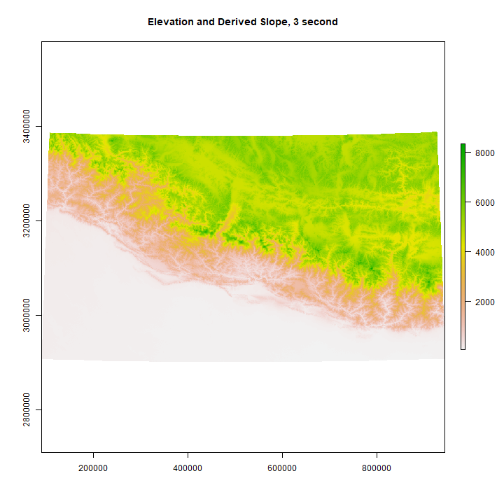

### Health Facilities, 2015

**Folder:** HealthFac  
**File Name:** npl_hltfac_DoH_WHO_wgs84.shp  
**Source:** The source of the data Survey Department of Nepal (http://ngiip.gov.np/) and data sponsor is WHO (World Health Organization).  
**Description:** This dataset depicts the Health Infrastructure of Nepal as points and was downloaded from the Humanitarian Data Exchange, https://data.humdata.org/dataset/nepal-health-facilities-cod  
**Class:** point  
**Derived Covariates:**  
cls, dst,

```
class       : SpatialPointsDataFrame
features    : 8975
extent      : 117496, 913430, 2923481, 3362222  (xmin, xmax, ymin, ymax)
coord. ref. : +proj=tmerc +lat_0=0 +lon_0=84 +k=0.9996 +x_0=500000 +y_0=0 +datum=WGS84 +units=m +no_defs +ellps=WGS84 +towgs84=0,0,0
variables   : 5
```

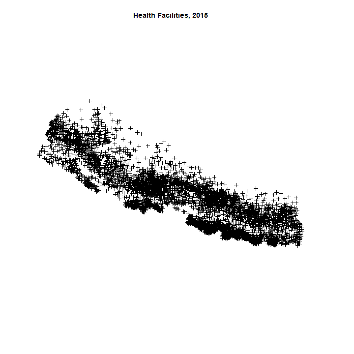

### Buildings, (OSM) 2017

**Folder:** Buildings  
**File Name:** bldings_osm_repaired.shp  
**Source:** Open Street Map, Downloaded 2017-07, http://extract.bbbike.org/  
**Description:** These data were downloaded as part of a per-country package of data layers made availalble as shapefiles through the http://extract.bbbike.org website, extracted from the Open Street Map (OSM) database. Distance to nearest feature was then calculated.  
**Class:** polygon  
**Derived Covariates:**  
cls, dst,

```
class       : SpatialPolygonsDataFrame
features    : 2528572
extent      : 112286, 917245, 2923763, 3349518  (xmin, xmax, ymin, ymax)
coord. ref. : +proj=tmerc +lat_0=0 +lon_0=84 +k=0.9996 +x_0=500000 +y_0=0 +datum=WGS84 +units=m +no_defs +ellps=WGS84 +towgs84=0,0,0
variables   : 5
```

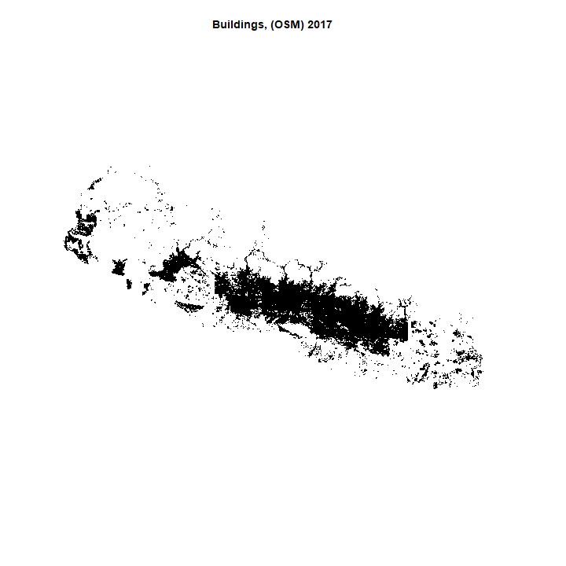

### Residential Areas, (OSM) 2017

**Folder:** Residential  
**File Name:** residential_osm.shp  
**Source:** Open Street Map, Downloaded 2017-07, http://extract.bbbike.org/  
**Description:** These data were downloaded as part of a per-country package of data layers made availalble as shapefiles through the http://extract.bbbike.org website, extracted from the Open Street Map (OSM) database. Distance to nearest feature was then calculated.  
**Class:** polygon  
**Derived Covariates:**  
cls, dst,

```
class       : SpatialPolygonsDataFrame
features    : 49448
extent      : 118871, 920159, 2918612, 3347951  (xmin, xmax, ymin, ymax)
coord. ref. : +proj=tmerc +lat_0=0 +lon_0=84 +k=0.9996 +x_0=500000 +y_0=0 +datum=WGS84 +units=m +no_defs +ellps=WGS84 +towgs84=0,0,0
variables   : 4
```

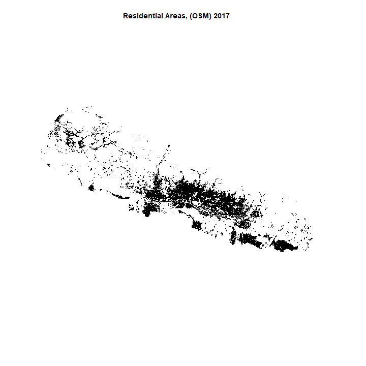

### Places (OSM) 2017

**Folder:** Places  
**File Name:** places_osm.shp  
**Source:** Open Street Map, Downloaded 2017-07, http://extract.bbbike.org/  
**Description:** These data were downloaded as part of a per-country package of data layers made availalble as shapefiles through the http://extract.bbbike.org website, extracted from the Open Street Map (OSM) database. Distance to nearest feature was then calculated.  
**Class:** polygon  
**Derived Covariates:**  
cls, dst,

```
class       : SpatialPolygonsDataFrame
features    : 468
extent      : 119897, 924200, 2937850, 3378350  (xmin, xmax, ymin, ymax)
coord. ref. : +proj=tmerc +lat_0=0 +lon_0=84 +k=0.9996 +x_0=500000 +y_0=0 +datum=WGS84 +units=m +no_defs +ellps=WGS84 +towgs84=0,0,0
variables   : 5
```

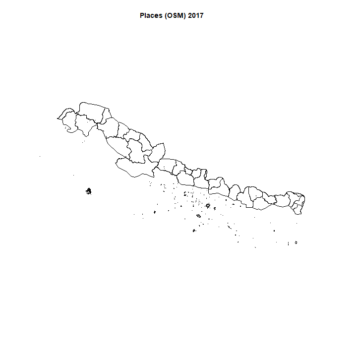

### Roads Network, Distance-to (OSM) 2017

**Folder:** Roads  
**File Name:** roads_distanceto.tif  
**Source:** Open Street Map, Downloaded 2017-07, http://extract.bbbike.org/  
**Description:** These data were downloaded as part of a per-country package of data layers made availalble as shapefiles through the http://extract.bbbike.org website, extracted from the Open Street Map (OSM) database. Distance to nearest feature was then calculated.  
**Class:** linear  
**Derived Covariates:**  
cls, dst,

```
class       : SpatialLinesDataFrame
features    : 755
extent      : 105800, 926191, 2911016, 3377678  (xmin, xmax, ymin, ymax)
coord. ref. : +proj=tmerc +lat_0=0 +lon_0=84 +k=0.9996 +x_0=500000 +y_0=0 +datum=WGS84 +units=m +no_defs +ellps=WGS84 +towgs84=0,0,0
variables   : 13
```

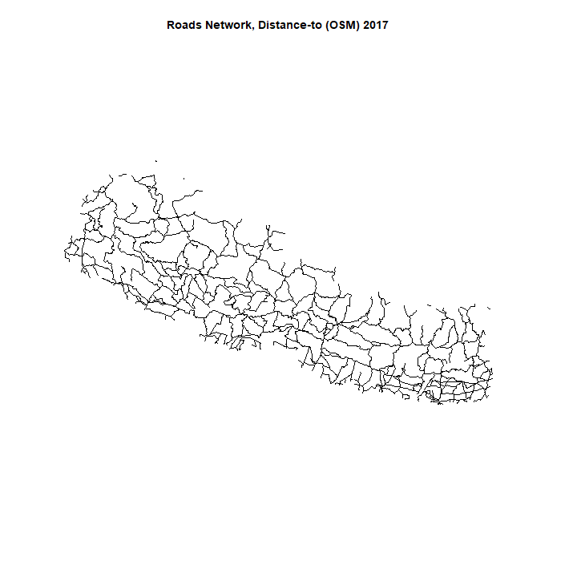

### Global Urban Footprint, 12m, 2015, Distance-to-Edge

**Folder:** GUF  
**File Name:** GUF+2015_Nepal_prj_dte.tif  
**Source:** Global Urban Footprint, 2016, DLR Earth Observation Center, http://www.dlr.de/eoc/  
**Description:** High Resolution Settlement Layer, open source data from Facebook's Connectivity Lab and the Center for International Earth Science Information Network (CIESIN)  
**Class:** raster  
**Derived Covariates:**  
,

```
class       : RasterBrick
dimensions  : 4826, 8156, 39360856, 1  (nrow, ncol, ncell, nlayers)
resolution  : 100, 100  (x, y)
extent      : 114672, 930272, 2903869, 3386469  (xmin, xmax, ymin, ymax)
coord. ref. : +proj=tmerc +lat_0=0 +lon_0=84 +k=0.9996 +x_0=500000 +y_0=0 +datum=WGS84 +units=m +no_defs +ellps=WGS84 +towgs84=0,0,0
data source : D:\Working_RF\data\NPL\GUF\Derived\guf.tif
names       :   guf
min values  :  -721
max values  : 67617
```

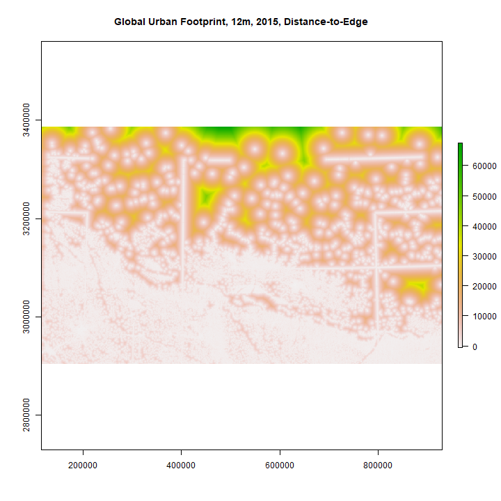

### Facebook Settlement layer

**Folder:** Facebook_DTE  
**File Name:** NPL_FB_DTE.tif  
**Source:** Facebook's Connectivity Lab and the Center for International Earth Science Information Network (CIESIN), http://ciesin.columbia.edu/data/hrsl/  
**Description:** These data were provided under a cooperation agreement with the GHSL project under the ECJRC as the 2014 beta versions and were converted to binary datasets at 38m.  
**Class:** raster  
**Derived Covariates:**  
,

```
class       : RasterBrick
dimensions  : 5161, 8437, 43543357, 1  (nrow, ncol, ncell, nlayers)
resolution  : 100, 100  (x, y)
extent      : 86672, 930372, 2890969, 3407069  (xmin, xmax, ymin, ymax)
coord. ref. : +proj=tmerc +lat_0=0 +lon_0=84 +k=0.9996 +x_0=500000 +y_0=0 +datum=WGS84 +units=m +no_defs +ellps=WGS84 +towgs84=0,0,0
data source : D:\Working_RF\data\NPL\Facebook_DTE\Derived\facebook_dte.tif
names       : facebook_dte
min values  :         -707
max values  :        12323
```

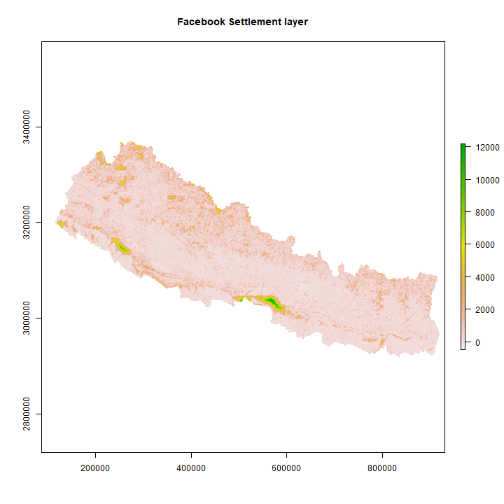

### Global Human Settlement Layer Beta, 38m, 2015, Distance-to-Edge

**Folder:** GHSL  
**File Name:** GHSL_100m_NPL_binary_WGS84_projected_DTE.tif  
**Source:** Global Human Settlement Layer, 2015, ECJRC, http://ghslsys.jrc.ec.europa.eu  
**Description:** NA  
**Class:** raster  
**Derived Covariates:**  
,

[output not shown]

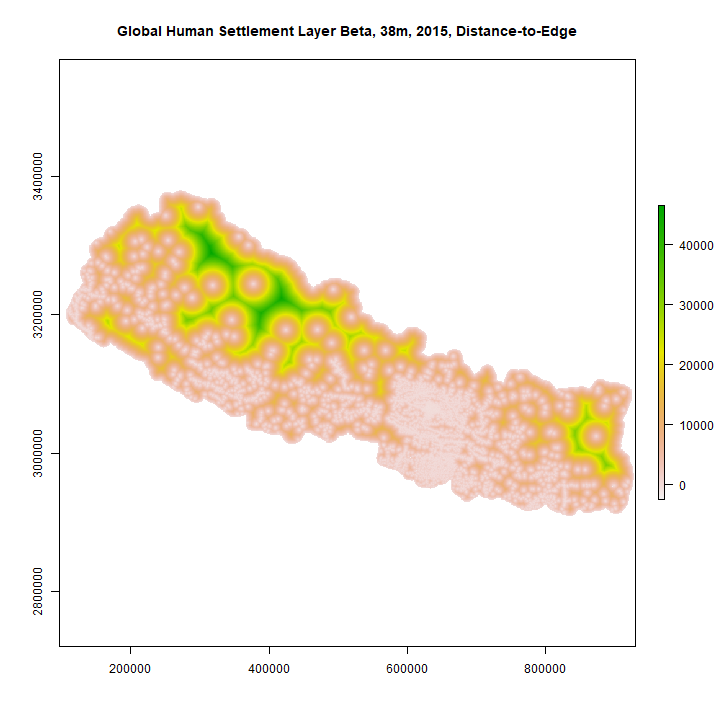